# Categorial Variables and Factors Assignment

# Please complete all the tasks listed below. After completing the tasks download the .Rmd file and upload in the peer review item for grading.

# Additionally please write text between the code chunks explaining what each code chunk is about.

# Refer the linked online textbook in case of any issues.

Load the stringr and forcats library

```r
library(stringr)
library(forcats)
library(ggplot2)
```

1.From the “forcats” library load gss_cat data. Explore the distribution of rincome (reported income). What makes the default bar chart hard to understand? How could you improve the plot?

Here is the default bar chart, the x labels are only partially available and it’s not clear where the non-labeled ones are. The labels are in descending order.

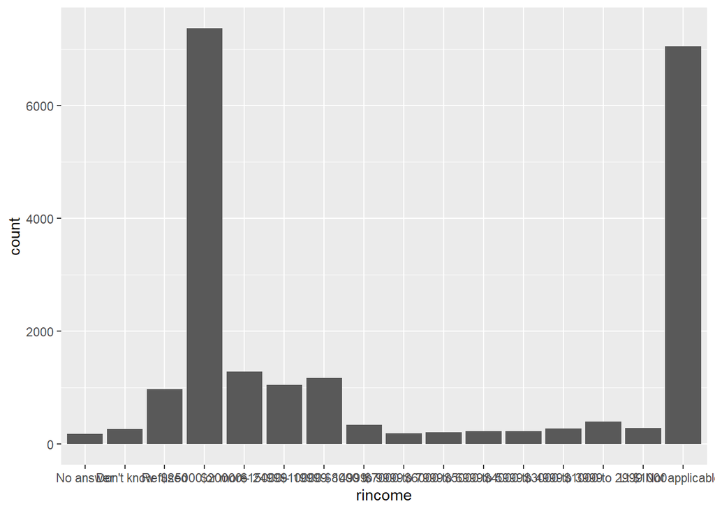

```r
plot <- ggplot(gss_cat, aes(rincome)) +
  geom_bar() +
  scale_x_discrete(drop = FALSE)

plot
```

To improve the chart, use factors and fix the labels.

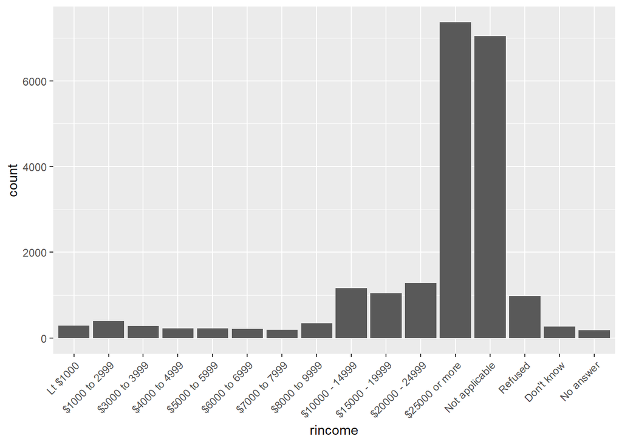

```r
income_levels <- c("Lt $1000", "$1000 to 2999", "$3000 to 3999", "$4000 to 4999",
                   "$5000 to 5999", "$6000 to 6999", "$7000 to 7999", "$8000 to 9999",
                   "$10000 - 14999", "$15000 - 19999", "$20000 - 24999", "$25000 or more",
                   "Not applicable", "Refused", "Don't know", "No answer")

# Convert rincome to a factor with defined levels
gss_cat$rincome <- factor(gss_cat$rincome, levels = income_levels)

# Plot
plot <- ggplot(gss_cat, aes(x = rincome)) +
  geom_bar() +
  scale_x_discrete(drop = FALSE) +  # Ensures all levels are shown
  theme(axis.text.x = element_text(angle = 45, hjust = 1))  # Improve label readability

plot
```

2. What is the most common religion? What is the most common partyid?

Most common party is independent. Most common religion is Protestant.

```r
data <- forcats::gss_cat

#Look at the parties
summary(data$partyid)
```

```
##          No answer         Don't know        Other party  Strong republican
##                154                  1                393               2314
## Not str republican       Ind,near rep        Independent       Ind,near dem
##               3032               1791               4119               2499
##   Not str democrat    Strong democrat
##               3690               3490
```

```r
##The max partyID from the data set is:
max(summary(data$partyid))
```

```
## [1] 4119
```

```r
which.max(table(data$partyid))
```

```
## Independent
##           7
```

```r
#Look at the religions
summary(data$relig)
```

```
##               No answer              Don't know Inter-nondenominational
##                      93                      15                     109
##         Native american               Christian      Orthodox-christian
##                      23                     689                      95
##            Moslem/islam           Other eastern                Hinduism
##                     104                      32                      71
##                Buddhism                   Other                    None
##                     147                     224                    3523
##                  Jewish                Catholic              Protestant
##                     388                    5124                   10846
##          Not applicable
##                       0
```

```r
##The max religion from the data set is:
max(summary(data$relig))
```

```
## [1] 10846
```

```r
which.max(table(data$relig))
```

```
## Protestant
##         15
```

3.Which relig does denom (denomination) apply to? How can you find out with a table? How can you find out with a visualisation?

```r
data <- forcats::gss_cat

# Create a contingency table
table_relig_denom <- table(data$relig, data$denom)

knitr::kable(table_relig_denom)
```

|  | No answer | Don’t know | No denomination | Other | Episcopal | Presbyterian-dk wh | Presbyterian, merged | Other presbyterian | United pres ch in us | Presbyterian c in us | Lutheran-dk which | Evangelical luth | Other lutheran | Wi evan luth synod | Lutheran-mo synod | Luth ch in america | Am lutheran | Methodist-dk which | Other methodist | United methodist | Afr meth ep zion | Afr meth episcopal | Baptist-dk which | Other baptists | Southern baptist | Nat bapt conv usa | Nat bapt conv of am | Am bapt ch in usa | Am baptist asso | … |
| --- | --- | --- | --- | --- | --- | --- | --- | --- | --- | --- | --- | --- | --- | --- | --- | --- | --- | --- | --- | --- | --- | --- | --- | --- | --- | --- | --- | --- | --- | --- |
| No answer | 93 | 0 | 0 | 0 | 0 | 0 | 0 | 0 | 0 | 0 | 0 | 0 | 0 | 0 | 0 | 0 | 0 | 0 | 0 | 0 | 0 | 0 | 0 | 0 | 0 | 0 | 0 | 0 | 0 | … |
| Don’t know | 0 | 0 | 0 | 0 | 0 | 0 | 0 | 0 | 0 | 0 | 0 | 0 | 0 | 0 | 0 | 0 | 0 | 0 | 0 | 0 | 0 | 0 | 0 | 0 | 0 | 0 | 0 | 0 | 0 | … |
| Inter-nondenominational | 0 | 0 | 0 | 0 | 0 | 0 | 0 | 0 | 0 | 0 | 0 | 0 | 0 | 0 | 0 | 0 | 0 | 0 | 0 | 0 | 0 | 0 | 0 | 0 | 0 | 0 | 0 | 0 | 0 | … |
| Native american | 0 | 0 | 0 | 0 | 0 | 0 | 0 | 0 | 0 | 0 | 0 | 0 | 0 | 0 | 0 | 0 | 0 | 0 | 0 | 0 | 0 | 0 | 0 | 0 | 0 | 0 | 0 | 0 | 0 | … |
| Christian | 2 | 11 | 452 | 0 | 0 | 0 | 0 | 0 | 0 | 0 | 0 | 0 | 0 | 0 | 0 | 0 | 0 | 0 | 0 | 0 | 0 | 0 | 0 | 0 | 0 | 0 | 0 | 0 | 0 | … |
| Orthodox-christian | 0 | 0 | 0 | 0 | 0 | 0 | 0 | 0 | 0 | 0 | 0 | 0 | 0 | 0 | 0 | 0 | 0 | 0 | 0 | 0 | 0 | 0 | 0 | 0 | 0 | 0 | 0 | 0 | 0 | … |
| Moslem/islam | 0 | 0 | 0 | 0 | 0 | 0 | 0 | 0 | 0 | 0 | 0 | 0 | 0 | 0 | 0 | 0 | 0 | 0 | 0 | 0 | 0 | 0 | 0 | 0 | 0 | 0 | 0 | 0 | 0 | … |
| Other eastern | 0 | 0 | 0 | 0 | 0 | 0 | 0 | 0 | 0 | 0 | 0 | 0 | 0 | 0 | 0 | 0 | 0 | 0 | 0 | 0 | 0 | 0 | 0 | 0 | 0 | 0 | 0 | 0 | 0 | … |
| Hinduism | 0 | 0 | 0 | 0 | 0 | 0 | 0 | 0 | 0 | 0 | 0 | 0 | 0 | 0 | 0 | 0 | 0 | 0 | 0 | 0 | 0 | 0 | 0 | 0 | 0 | 0 | 0 | 0 | 0 | … |
| Buddhism | 0 | 0 | 0 | 0 | 0 | 0 | 0 | 0 | 0 | 0 | 0 | 0 | 0 | 0 | 0 | 0 | 0 | 0 | 0 | 0 | 0 | 0 | 0 | 0 | 0 | 0 | 0 | 0 | 0 | … |
| Other | 0 | 0 | 7 | 0 | 0 | 0 | 0 | 0 | 0 | 0 | 0 | 0 | 0 | 0 | 0 | 0 | 0 | 0 | 0 | 0 | 0 | 0 | 0 | 0 | 0 | 0 | 0 | 0 | 0 | … |
| None | 0 | 0 | 0 | 0 | 0 | 0 | 0 | 0 | 0 | 0 | 0 | 0 | 0 | 0 | 0 | 0 | 0 | 0 | 0 | 0 | 0 | 0 | 0 | 0 | 0 | 0 | 0 | 0 | 0 | … |
| Jewish | 0 | 0 | 0 | 0 | 0 | 0 | 0 | 0 | 0 | 0 | 0 | 0 | 0 | 0 | 0 | 0 | 0 | 0 | 0 | 0 | 0 | 0 | 0 | 0 | 0 | 0 | 0 | 0 | 0 | … |
| Catholic | 0 | 0 | 0 | 0 | 0 | 0 | 0 | 0 | 0 | 0 | 0 | 0 | 0 | 0 | 0 | 0 | 0 | 0 | 0 | 0 | 0 | 0 | 0 | 0 | 0 | 0 | 0 | 0 | 0 | … |
| Protestant | 22 | 41 | 1224 | 2534 | 397 | 244 | 67 | 47 | 110 | 104 | 267 | 122 | 30 | 71 | 212 | 71 | 146 | 239 | 33 | 1067 | 32 | 77 | 1457 | 213 | 1536 | 40 | 76 | 130 | 237 | … |
| Not applicable | 0 | 0 | 0 | 0 | 0 | 0 | 0 | 0 | 0 | 0 | 0 | 0 | 0 | 0 | 0 | 0 | 0 | 0 | 0 | 0 | 0 | 0 | 0 | 0 | 0 | 0 | 0 | 0 | 0 | … |

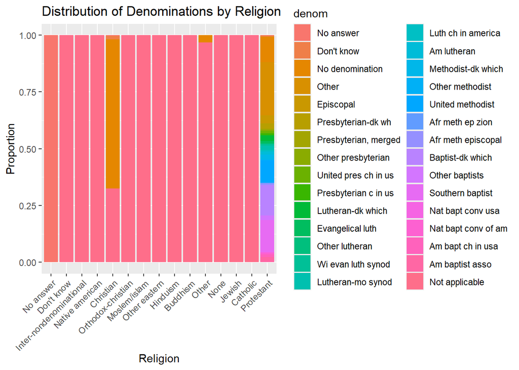

```r
# Plot
ggplot(data, aes(x = relig, fill = denom)) +
  geom_bar(position = "fill") +
  theme(axis.text.x = element_text(angle = 45, hjust = 1)) +
  labs(title = "Distribution of Denominations by Religion", x = "Religion", y = "Proportion")
```

4.How have the proportions of people identifying as Democrat, Republican, and Independent changed over time? Plot a suitable chart.

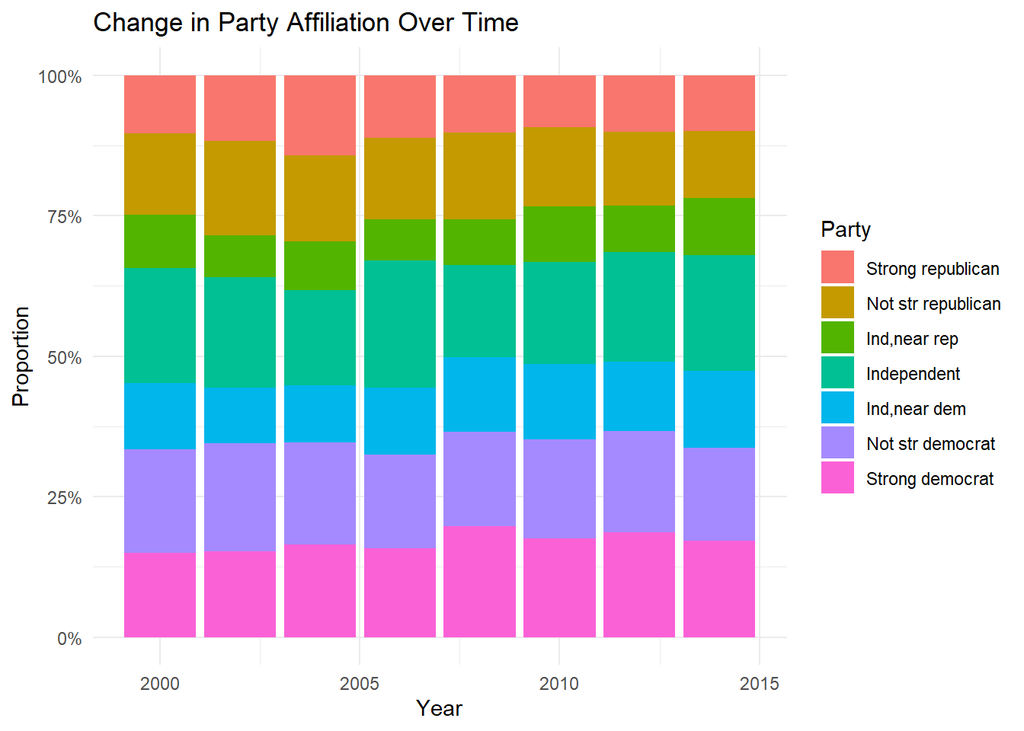

```r
library(ggplot2)
library(dplyr)
# Prepare the data by grouping and summarizing
party_time_series <- data %>%
  group_by(year, partyid) %>%
  summarise(count = n(), .groups = "drop") %>%
  mutate(total = sum(count), proportion = count / total)

# Filter for major party categories to simplify the plot
party_time_series <- party_time_series %>%
  filter(partyid %in% c("Strong democrat", "Not str democrat", "Independent", "Strong republican", "Not str republican", "Ind,near dem", "Ind,near rep"))

# Plotting
ggplot(party_time_series, aes(x = year, y = proportion, fill = partyid)) +
  geom_bar(stat = "identity", position = "fill") +
  scale_y_continuous(labels = scales::percent_format()) +
  labs(x = "Year", y = "Proportion", title = "Change in Party Affiliation Over Time", fill = "Party") +
  theme_minimal()
```

5.Collapse “rincome” into smaller set of categories?

```r
library(dplyr)

# Assuming 'data' is your dataframe and 'rincome' is the income column

# Recategorize income into broader categories
data <- data %>%
  mutate(rincome_group = case_when(
    rincome %in% c("$3000 to 3999", "$5000 to 5999", "$8000 to 9999", "$7000 to 7999", "$1000 to 2999", "Lt $1000") ~ "Low Income",
    rincome %in% c("$10000 - 14999", "$15000 - 19999", "$20000 - 24999") ~ "Middle Income",
    rincome %in% c("$25000 or more") ~ "High Income",
    rincome %in% c("Not applicable", "Refused", "Don't know", "No answer") ~ "Unknown",
    TRUE ~ "Other"
  ))

# Check the modified data
table(data$rincome_group)
```

```
##
##   High Income    Low Income Middle Income         Other       Unknown
##          7363          1712          3499           441          8468
```